# **The Data Behind Music and What We Like to Hear**

#### **Standarized Popularity Graphs**

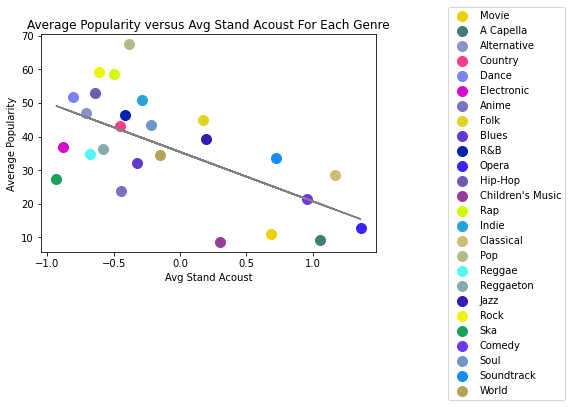

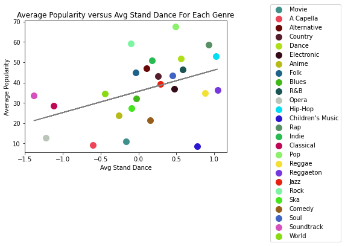

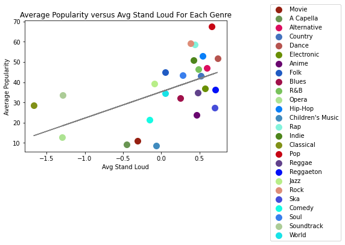

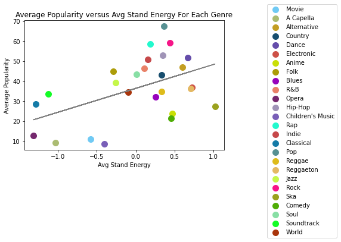

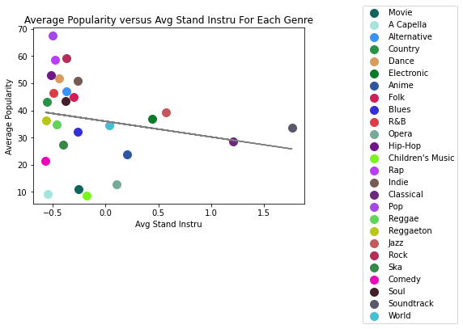

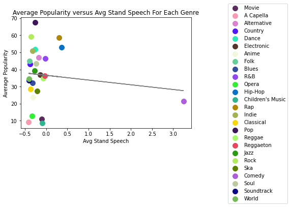

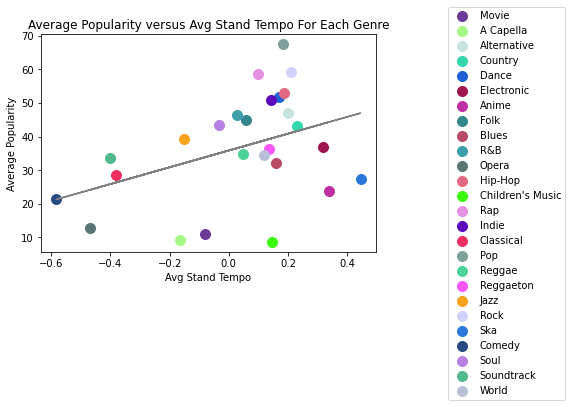

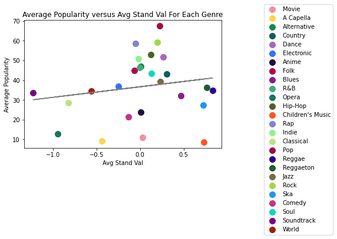

```python
audio_features = ['Avg Stand Acoust', 'Avg Stand Dance','Avg Stand Loud','Avg Stand Energy','Avg Stand Instru','Avg Stand Speech','Avg Stand Tempo','Avg Stand Val']
for a in audio_features:
    sequence = np.arange(len(data.genre.unique()))
    for co in sequence:
        rgb = np.random.rand(3,)
        plt.scatter(genre_count[a][co], genre_count['Avg Pop'][co], s =100, c = [rgb], label = list(genre_count["genre"])[co])


    plt.ylabel("Average Popularity", size=10)
    plt.xlabel(a, size=10)
    plt.title("Average Popularity versus " + a + " For Each Genre")
    plt.legend(loc="upper left", bbox_to_anchor=(1.2, 1.15))

    m, b = np.polyfit(genre_count[a], genre_count['Avg Pop'], 1)
    plt.plot(genre_count[a], m*(genre_count[a])+b, color = "gray")

    plt.show()
```

Across all of the standardized plots, the trend of the data is exactly the same as the non-standardized version of the plots. Due to this, our visual interpretation of the standardized plots remains the same as the non-standardized plots. As standardization makes it such that all of the audio features are measured on the same scale, we can compare visually how much the data for each audio feature varies. Generally, most of the data in each standardized plot lie within the -0.5 to 0.5 range with the exception of acousticness. The three features with the tightest distribution of data appear to be tempo, valence, and speechiness (excluding the outlier of the Comedy genre). On the other hand, danceability and acousticness appear to have the greatest ranges of data among the audio features.

#### **Now, we're going to create a heatmap.**

We want to ensure we have a good understanding of the relationships presented in our data. We are going to perform a correlation heatmap to get a better look at correlations and specifically look at the ones related to popularity and valence.

For more information on heatmaps: https://www.geeksforgeeks.org/seaborn-heatmap-a-comprehensive-guide/

Specifically correlation heatmaps: https://www.geeksforgeeks.org/how-to-create-a-seaborn-correlation-heatmap-in-python/, https://medium.com/@szabo.bibor/how-to-create-a-seaborn-correlation-heatmap-in-python-834c0686b88e, or https://vitalflux.com/correlation-heatmap-with-seaborn-pandas/

Documentation: https://seaborn.pydata.org/generated/seaborn.heatmap.html

```python
import seaborn as sbn
```

```python
#first create the correlation matrix the correlation heatmap will be based upon

#corr computes the pairwise correlation of columns and by default uses the Pearson method of correlation

#note: we are going to look at the original dataframe (the one without the standardization columns in it)
data.corr()
```

|  | popularity | acousticness | danceability | duration_ms | energy | instrumentalness | liveness | loudness | speechiness | tempo | valence |
| --- | --- | --- | --- | --- | --- | --- | --- | --- | --- | --- | --- |
| popularity | 1.000000 | -0.327390 | 0.165404 | 0.042025 | 0.217593 | -0.067832 | -0.144750 | 0.270917 | -0.169741 | 0.078863 | 0.036097 |
| acousticness | -0.327390 | 1.000000 | -0.381525 | 0.007794 | -0.730745 | 0.287374 | 0.082477 | -0.691342 | 0.191569 | -0.279329 | -0.368998 |
| danceability | 0.165404 | -0.381525 | 1.000000 | -0.123537 | 0.391779 | -0.369915 | -0.009618 | 0.471858 | 0.136244 | 0.064934 | 0.623282 |
| duration_ms | 0.042025 | 0.007794 | -0.123537 | 1.000000 | -0.029151 | 0.063446 | 0.022543 | -0.038694 | -0.008927 | -0.030635 | -0.151709 |
| energy | 0.217593 | -0.730745 | 0.391779 | -0.029151 | 1.000000 | -0.397413 | 0.229694 | 0.830228 | 0.176687 | 0.250577 | 0.460423 |
| instrumentalness | -0.067832 | 0.287374 | -0.369915 | 0.063446 | -0.397413 | 1.000000 | -0.190997 | -0.491609 | -0.207296 | -0.109790 | -0.348598 |
| liveness | -0.144750 | 0.082477 | -0.009618 | 0.022543 | 0.229694 | -0.190997 | 1.000000 | 0.073833 | 0.588438 | -0.071577 | 0.001270 |
| loudness | 0.270917 | -0.691342 | 0.471858 | -0.038694 | 0.830228 | -0.491609 | 0.073833 | 1.000000 | 0.005213 | 0.259412 | 0.450317 |
| speechiness | -0.169741 | 0.191569 | 0.136244 | -0.008927 | 0.176687 | -0.207296 | 0.588438 | 0.005213 | 1.000000 | -0.119374 | 0.015196 |
| tempo | 0.078863 | -0.279329 | 0.064934 | -0.030635 | 0.250577 | -0.109790 | -0.071577 | 0.259412 | -0.119374 | 1.000000 | 0.179346 |
| valence | 0.036097 | -0.368998 | 0.623282 | -0.151709 | 0.460423 | -0.348598 | 0.001270 | 0.450317 | 0.015196 | 0.179346 | 1.000000 |

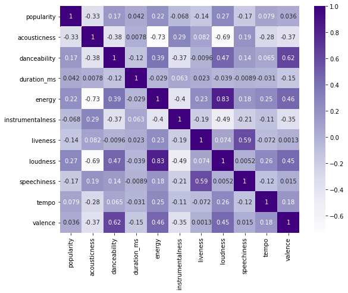

```python
#next create the more visually appealing heatmap
plt.figure(figsize=(9, 7))
corr_heat_map = sbn.heatmap(data.corr(), annot = True, cmap = 'Purples')
plt.show()
```

#### **Analysis of the heatmap**

In order to analyze the heatmap, you have to first understand what is represents. I recommend taking a look at the Medium, GeeksForGeeks, or Data Analytics article (all linked above) to get some more insight, but I will also quickly go through it here alongside my analysis.

A correlation heatmap is a visual representation of a correlation matrix. It essentially, as suggested by the name, allows one to get a visual and easily interpretable understanding of the correlation between two variables in our dataset. The color bar on the side of the heat map will allow us to determine which colors are associated with a strong positive or negative correlation or may have no correlation at all. I decided to use the monochromic purple scale to make it more interpretable because the default colors can be a bit confusing to interpret. Our main focus for our analysis is looking at the popularity and valence row/column and determining which audio features have the strongest correlation (positive or negative) to it.

##### **Popularity**:

So much like we could tell from our plots earlier, acousticness and popularity have a negative correlation to each other (and it is correlation that we see in the popularity column). Also, we can also see that instrumentalness, valence, duration, and tempo dont have such a strong correlation either (though important to note that tempo has the highest absolute value among these and is positive so might have some slight importance in our analysis). These findings (excluding duration which we did not plot) match what we saw and talked about above. We chose not to plot duration because we doubted that there would be any sort of relationship which this confirms. We see that danceability, energy, and loudness have a somewhat positive correlation which again reaffirms what we saw in our graphs.

One surprising thing was that liveness was as high as it was (even though not a lot). We can see it has somewhat of a negative correlation to popularity. We excluded this from our initially grpahing cause we did nto thing it would have nay sort of impact, so seeing it have a stronger correlation to some of the other variables we analyzed is interesting. We are still not going to include this variable in our anaylsis and hypothesis because it is not strong enough. Another suprising thing we see is that speech is as strong as danceibility when we initially said it had not much of a correlation.

Also, important to note a lot of the correlation values are not very high.

##### **Valence**:

We can immediately see that valence has the strongest relationship with danceability. It has a somewhat high positive correlation value. We also notice it has a somewhat strong positive correlation to energy and loudness. This makes sense cause dance music tends to be upbeat and fun as would louder and higher energy music. There is almost no relationship between popularity and valence, speechiness and valence, and liveness and valence. It is suprising that there is no relationship between valence and popularity because we thought that maybe certain moods of music would be more popular. There is a somewhat negative relationship between acousticness and valence and instrumentalness and valence which again makes sense.

Also, important to note a lot of the correlation values are not very high, but in general higher than those in popularity.

##### **Other Important Things to Note**:

There is a very strong positive relationship between energy and loudness which we will need to take into account if we looking at other relationships with these variables. There is also a somewhat positive relationship between danceability and energy and danceability and loudness. This will also need to be taken into account. Finally there is also a pretty strong negative relationship with acousticness and energy and loudness.

#### Now that we have a good understanding of the relationships that are present in the data, we are going to do a more thorough statistical analysis.

We are specifically going look at the stronger popularity relationships present (specifically the ones we talked about above) adn the stronger valence relationships present. We will be looking at the R^2 value and the p value for these relationships and at timews will include interaction variables. Please reference the sources below if you would like additional reading on any of these. In order to do this we will be using statsmodels ols regession results. Important to note if the p value is less than 0.05 than statistically significant and we would prefer a somewhat high R^2 value (coefficient of determination).

R^2: https://www.investopedia.com/terms/r/r-squared.asp

p value: https://measuringu.com/statistically-significant/

Interaction: https://stattrek.com/multiple-regression/interaction.aspx https://www.statsmodels.org/dev/example_formulas.html#multiplicative-interactions

```python
import statsmodels.api as sm
import statsmodels.formula.api as smf
```

#### **Valence Relationships**

We're first going to start with looking at the valence relationship. As we mentioned earlier there appears to be a very strong relationship between valence and dancebility so that is the first relationship we are going ot look at.

```python
r = (smf.ols(formula='valence ~ danceability', data=data)).fit()
r.summary()
```

OLS Regression Results

| Dep. Variable: | valence | R-squared: | 0.388 |
| --- | --- | --- | --- |
| Model: | OLS | Adj. R-squared: | 0.388 |
| Method: | Least Squares | F-statistic: | 8.999e+04 |
| Date: | Sat, 11 Dec 2021 | Prob (F-statistic): | 0.00 |
| Time: | 07:02:48 | Log-Likelihood: | 16835. |
| No. Observations: | 141650 | AIC: | -3.367e+04 |
| Df Residuals: | 141648 | BIC: | -3.365e+04 |
| Df Model: | 1 |  |  |
| Covariance Type: | nonrobust |  |  |

|  | coef | std err | t | P>\|t\| | [0.025 | 0.975] |
| --- | --- | --- | --- | --- | --- | --- |
| Intercept | -0.0185 | 0.002 | -11.128 | 0.000 | -0.022 | -0.015 |
| danceability | 0.8849 | 0.003 | 299.975 | 0.000 | 0.879 | 0.891 |

| Omnibus: | 822.031 | Durbin-Watson: | 1.615 |
| --- | --- | --- | --- |
| Prob(Omnibus): | 0.000 | Jarque-Bera (JB): | 731.501 |
| Skew: | 0.131 | Prob(JB): | 1.43e-159 |
| Kurtosis: | 2.766 | Cond. No. | 6.65 |

Notes:  
[1] Standard Errors assume that the covariance matrix of the errors is correctly specified.

So the p value is less than 0.05 which means it is statisitically significant which is good. The R^2 value is not very high so there might be some interation terms we want to look at. As we mentioned earlier, there is some relationship with danceability and energy and loudnesss, so let's add those as interaction variables.

```python
r = (smf.ols(formula='valence ~ danceability*energy*loudness', data=data)).fit()
r.summary()
```

OLS Regression Results

| Dep. Variable: | valence | R-squared: | 0.446 |
| --- | --- | --- | --- |
| Model: | OLS | Adj. R-squared: | 0.446 |
| Method: | Least Squares | F-statistic: | 1.631e+04 |
| Date: | Sat, 11 Dec 2021 | Prob (F-statistic): | 0.00 |
| Time: | 07:02:49 | Log-Likelihood: | 23877. |
| No. Observations: | 141650 | AIC: | -4.774e+04 |
| Df Residuals: | 141642 | BIC: | -4.766e+04 |
| Df Model: | 7 |  |  |
| Covariance Type: | nonrobust |  |  |

|  | coef | std err | t | P>\|t\| | [0.025 | 0.975] |
| --- | --- | --- | --- | --- | --- | --- |
| Intercept | -0.0672 | 0.009 | -7.306 | 0.000 | -0.085 | -0.049 |
| danceability | 0.6716 | 0.018 | 37.628 | 0.000 | 0.637 | 0.707 |
| energy | 0.3988 | 0.011 | 35.001 | 0.000 | 0.377 | 0.421 |
| danceability:energy | -0.2115 | 0.022 | -9.430 | 0.000 | -0.255 | -0.168 |
| loudness | -0.0005 | 0.000 | -1.258 | 0.208 | -0.001 | 0.000 |
| danceability:loudness | -0.0029 | 0.001 | -3.284 | 0.001 | -0.005 | -0.001 |
| energy:loudness | 0.0235 | 0.001 | 21.439 | 0.000 | 0.021 | 0.026 |
| danceability:energy:loudness | -0.0383 | 0.002 | -18.127 | 0.000 | -0.042 | -0.034 |

| Omnibus: | 124.022 | Durbin-Watson: | 1.617 |
| --- | --- | --- | --- |
| Prob(Omnibus): | 0.000 | Jarque-Bera (JB): | 108.099 |
| Skew: | -0.008 | Prob(JB): | 3.36e-24 |
| Kurtosis: | 2.866 | Cond. No. | 793. |

Notes:  
[1] Standard Errors assume that the covariance matrix of the errors is correctly specified.

By adding the interaction variables there is an increase in the R^2 value which is good. The interaction term between the three variables is staticallys significant because it is less than 0.05. This would be a better relationship to look at overall.

#### **Popularity Relationships**

```python
#first going to look at the statistical relationship between popularity and acousticness
r = (smf.ols(formula='popularity ~ acousticness', data=data)).fit()
r.summary()
```

OLS Regression Results

| Dep. Variable: | popularity | R-squared: | 0.107 |
| --- | --- | --- | --- |
| Model: | OLS | Adj. R-squared: | 0.107 |
| Method: | Least Squares | F-statistic: | 1.701e+04 |
| Date: | Sat, 11 Dec 2021 | Prob (F-statistic): | 0.00 |
| Time: | 07:02:49 | Log-Likelihood: | -5.8437e+05 |
| No. Observations: | 141650 | AIC: | 1.169e+06 |
| Df Residuals: | 141648 | BIC: | 1.169e+06 |
| Df Model: | 1 |  |  |
| Covariance Type: | nonrobust |  |  |

|  | coef | std err | t | P>\|t\| | [0.025 | 0.975] |
| --- | --- | --- | --- | --- | --- | --- |
| Intercept | 38.0428 | 0.061 | 621.689 | 0.000 | 37.923 | 38.163 |
| acousticness | -13.8818 | 0.106 | -130.404 | 0.000 | -14.090 | -13.673 |

| Omnibus: | 80.179 | Durbin-Watson: | 0.366 |
| --- | --- | --- | --- |
| Prob(Omnibus): | 0.000 | Jarque-Bera (JB): | 72.785 |
| Skew: | 0.018 | Prob(JB): | 1.57e-16 |
| Kurtosis: | 2.895 | Cond. No. | 3.25 |

Notes:  
[1] Standard Errors assume that the covariance matrix of the errors is correctly specified.

This has a pretty low R^2 value, but it is statistically significant due to the p value being less than 0.05. Let's see if adding an interaction term between acousticness, energy, and loudness will increase the R^2 value.

```python
#notice there is strong correlation between acousticness and energy and acousticness and loudness
#as well as one for energy and loudness so decided to create interaction variables between them
r = (smf.ols(formula='popularity ~ acousticness*energy*loudness', data=data)).fit()
r.summary()
```

OLS Regression Results

| Dep. Variable: | popularity | R-squared: | 0.138 |
| --- | --- | --- | --- |
| Model: | OLS | Adj. R-squared: | 0.138 |
| Method: | Least Squares | F-statistic: | 3233. |
| Date: | Sat, 11 Dec 2021 | Prob (F-statistic): | 0.00 |
| Time: | 07:02:50 | Log-Likelihood: | -5.8190e+05 |
| No. Observations: | 141650 | AIC: | 1.164e+06 |
| Df Residuals: | 141642 | BIC: | 1.164e+06 |
| Df Model: | 7 |  |  |
| Covariance Type: | nonrobust |  |  |

|  | coef | std err | t | P>\|t\| | [0.025 | 0.975] |
| --- | --- | --- | --- | --- | --- | --- |
| Intercept | 65.6668 | 0.563 | 116.626 | 0.000 | 64.563 | 66.770 |
| acousticness | -41.2080 | 0.736 | -55.968 | 0.000 | -42.651 | -39.765 |
| energy | -30.2330 | 0.643 | -46.994 | 0.000 | -31.494 | -28.972 |
| acousticness:energy | 46.5223 | 0.923 | 50.397 | 0.000 | 44.713 | 48.332 |
| loudness | 1.5921 | 0.044 | 36.343 | 0.000 | 1.506 | 1.678 |
| acousticness:loudness | -1.6701 | 0.049 | -33.978 | 0.000 | -1.766 | -1.574 |
| energy:loudness | -1.0680 | 0.064 | -16.600 | 0.000 | -1.194 | -0.942 |
| acousticness:energy:loudness | 2.8878 | 0.084 | 34.349 | 0.000 | 2.723 | 3.053 |

| Omnibus: | 53.796 | Durbin-Watson: | 0.410 |
| --- | --- | --- | --- |
| Prob(Omnibus): | 0.000 | Jarque-Bera (JB): | 53.559 |
| Skew: | -0.044 | Prob(JB): | 2.34e-12 |
| Kurtosis: | 2.962 | Cond. No. | 557. |

Notes:  
[1] Standard Errors assume that the covariance matrix of the errors is correctly specified.

The R^2 value does increase, but not by a lot. The R^2 value is still pretty low though. This means that there is probably not a strong relationship between these and popularity. How about we now look at popularity and danceability.

```python
#next we're going to look at the relationship between danceability and popularity
r = (smf.ols(formula='popularity ~ danceability', data=data)).fit()
r.summary()
```

OLS Regression Results

| Dep. Variable: | popularity | R-squared: | 0.027 |
| --- | --- | --- | --- |
| Model: | OLS | Adj. R-squared: | 0.027 |
| Method: | Least Squares | F-statistic: | 3984. |
| Date: | Sat, 11 Dec 2021 | Prob (F-statistic): | 0.00 |
| Time: | 07:02:50 | Log-Likelihood: | -5.9044e+05 |
| No. Observations: | 141650 | AIC: | 1.181e+06 |
| Df Residuals: | 141648 | BIC: | 1.181e+06 |
| Df Model: | 1 |  |  |
| Covariance Type: | nonrobust |  |  |

|  | coef | std err | t | P>\|t\| | [0.025 | 0.975] |
| --- | --- | --- | --- | --- | --- | --- |
| Intercept | 24.8215 | 0.121 | 205.494 | 0.000 | 24.585 | 25.058 |
| danceability | 13.5467 | 0.215 | 63.121 | 0.000 | 13.126 | 13.967 |

| Omnibus: | 747.517 | Durbin-Watson: | 0.262 |
| --- | --- | --- | --- |
| Prob(Omnibus): | 0.000 | Jarque-Bera (JB): | 745.443 |
| Skew: | -0.167 | Prob(JB): | 1.35e-162 |
| Kurtosis: | 2.880 | Cond. No. | 6.65 |

Notes:  
[1] Standard Errors assume that the covariance matrix of the errors is correctly specified.

This again has a pretty low R^2 value, but it is statistically significant due to the p value being less than 0.05. Let's see if adding an interaction term between danceability , energy, and loudness will increase the R^2 value.

```python
r = (smf.ols(formula='popularity ~ danceability*energy*loudness', data=data)).fit()
r.summary()

#statistically signficant (less than 0.05), but again the R^2 value does increase but not by much
```

OLS Regression Results

| Dep. Variable: | popularity | R-squared: | 0.097 |
| --- | --- | --- | --- |
| Model: | OLS | Adj. R-squared: | 0.097 |
| Method: | Least Squares | F-statistic: | 2170. |
| Date: | Sat, 11 Dec 2021 | Prob (F-statistic): | 0.00 |
| Time: | 07:02:50 | Log-Likelihood: | -5.8518e+05 |
| No. Observations: | 141650 | AIC: | 1.170e+06 |
| Df Residuals: | 141642 | BIC: | 1.170e+06 |
| Df Model: | 7 |  |  |
| Covariance Type: | nonrobust |  |  |

|  | coef | std err | t | P>\|t\| | [0.025 | 0.975] |
| --- | --- | --- | --- | --- | --- | --- |
| Intercept | 21.6647 | 0.678 | 31.962 | 0.000 | 20.336 | 22.993 |
| danceability | 40.2316 | 1.315 | 30.590 | 0.000 | 37.654 | 42.809 |
| energy | 7.7351 | 0.840 | 9.213 | 0.000 | 6.089 | 9.381 |
| danceability:energy | -20.5465 | 1.653 | -12.431 | 0.000 | -23.786 | -17.307 |
| loudness | -0.3391 | 0.028 | -12.115 | 0.000 | -0.394 | -0.284 |
| danceability:loudness | 2.4312 | 0.065 | 37.637 | 0.000 | 2.305 | 2.558 |
| energy:loudness | 0.2329 | 0.081 | 2.889 | 0.004 | 0.075 | 0.391 |
| danceability:energy:loudness | -0.3339 | 0.156 | -2.144 | 0.032 | -0.639 | -0.029 |

| Omnibus: | 336.795 | Durbin-Watson: | 0.355 |
| --- | --- | --- | --- |
| Prob(Omnibus): | 0.000 | Jarque-Bera (JB): | 320.196 |
| Skew: | -0.094 | Prob(JB): | 2.95e-70 |
| Kurtosis: | 2.862 | Cond. No. | 793. |

Notes:  
[1] Standard Errors assume that the covariance matrix of the errors is correctly specified.

Good news is that all the tests above, show that these relationships are significant, but some relationships are strong than others. We can reject the following null hypotheses:

there is no relationship between danceability and valence

(even though the R^2 value is low, the p value is less than 0.05 so okay to reject null hypothesis)

there is no relationship between danceability and popularity

there is no relationship between acousticness and popularity

## **7. Machine Learning: Linear Regression**

We now want to apply machine learning to predicting popularity of music and valence of music based on specific audio features. We will focus on danceability, acousticness, and energy and loudness as those are the ones we found with stronger relationships to popularity and valence (especially in comparison to the other audio features).

We are first going to start with linear regression. Linear regression is a statistical operation that allows us to understand the relationship between numeric variables. The application of a linear model against what we define as the input and output variables is what linear regression uses to determine the characteristics of the relationship between the two types of variables. The model assumes that the output variables can be calculated from a linear combination of the input variables.

We are going to use the built in sklearn [LinearRegressinon](https://scikit-learn.org/stable/modules/generated/sklearn.linear_model.LinearRegression.html) implementation

Some other additional resources are: https://www.datacourses.com/evaluation-of-regression-models-in-scikit-learn-846/

These will help give more background and understanding of the metrics we will be using. These metrics are:

**RMSE (root mean squared error)** -- "the square root of the averaged squared difference between the target value and the value predicted by the model"

**R^2 (coefficient of determination)** -- "helps us to compare our current model with a constant baseline and tells us how much our model is better"

**MAE (Mean Absolute Error)** -- "absolute difference between the target value and the value predicted by the model"

(the above defintions are provied by https://towardsdatascience.com/regression-an-explanation-of-regression-metrics-and-what-can-go-wrong-a39a9793d914)

```python
#the imports needed to do the following analysis
import seaborn as sbn
import sklearn
from sklearn.linear_model import LinearRegression
from sklearn.model_selection import train_test_split
from sklearn.metrics import r2_score
from sklearn.metrics import mean_squared_error
from sklearn.metrics import mean_absolute_error
```

**LINEAR REGRESSION (POPULARITY)**

First, we will apply linear predicting popularity of music based on specific audio features. We will focus on danceability, acousticness, and energy and loudness as those are the ones we found with stronger relationships to popularity (especially in comparison to the other audio features).

First, we are going to look at the relationship we saw betweem acouticness and popularity along with the interaction variables energy and loudness.

```python
#Acousticness

#first going to split the data (70/30)
ml = data.copy()
y = ml['popularity']
X = ml.drop('popularity', axis = 1)

X_train, X_test, y_train, y_test = train_test_split(X, y, test_size = 0.3)
X_train = X_train.assign(popularity = y_train)

#fitting the model with the training data and interaction formula
acinter_reg = smf.ols(formula = 'popularity ~ acousticness*energy*loudness', data = X_train).fit()

#print out the parameters that represent the model
print("Parameters: ", acinter_reg.params)

#predict based on testing data
acint_y_pre = acinter_reg.predict(X_test)

#calculate coefficient of determination
rsqu = acinter_reg.rsquared


#compute Root Mean Square Error (RMSE) -- the standard deviation of the residuals
rmse = np.sqrt(mean_squared_error(y_test, acint_y_pre))

print("")
print("RMSE: ", rmse)
print("Coefficient of Determination(R^2): ", rsqu)
```

```
Parameters:  Intercept                       65.397196
acousticness                   -41.031618
energy                         -30.115619
acousticness:energy             46.041687
loudness                         1.570478
acousticness:loudness           -1.653618
energy:loudness                 -1.077288
acousticness:energy:loudness     2.866238
dtype: float64

RMSE:  14.72864043878591
Coefficient of Determination(R^2):  0.13677870656061186
```

The first thing we notice is that the R^2 (coefficient of determination) value is really low. This metric, as we mentioned earlier, is used to evaluate the performance of our regression model. It essentially tells us how much of the total variation in the target variable is explained by the variation in the regression line. A low R^2 value (like ours) indicates that our regression model is not a good fit for the depicted relationship. It does not account for enough of the variance. This is not great in terms of how acousticness impacts that of popularity. We also notice that our RMSE is pretty high.The RMSE is the square root of the averaged squared difference between the target value and the value predicted by the model. This means that the regression model we created is not a good fit for the dataset and a representation of predicting popularity based on acousticness, energy, and loudness. We could also argue that possibly the nature of the acousticness scale itself is not representative of popularity in music.

Now, we are going to look at the relationship we saw betweem danceability and popularity along with the interaction variables energy and loudness.

```python
#Danceability

#first split the data (70/30)
ml2 = data.copy()
yd = ml2['popularity']
Xd = ml2.drop('popularity', axis = 1)

X_traind, X_testd, y_traind, y_testd = train_test_split(Xd, yd, test_size = 0.3)
X_traind = X_train.assign(popularity = y_traind)

#fitting the model with the training data and interaction formula
dinter_reg = smf.ols(formula = 'popularity ~ danceability*energy*loudness', data = X_traind).fit()

#print out the parameters that represent the model
print("Parameters: ", dinter_reg.params)

#predict based on testing data
dint_y_pre = dinter_reg.predict(X_testd)

#calculate coefficient of determination
rsqud = dinter_reg.rsquared


#compute Root Mean Square Error (RMSE) -- the standard deviation of the residuals
rmsed = np.sqrt(mean_squared_error(y_testd, dint_y_pre))

print("")
print("RMSE: ", rmsed)
print("Coefficient of Determination (R^2): ", rsqud)
```

```
Parameters:  Intercept                       22.436277
danceability                    38.074842
energy                           7.295053
danceability:energy            -19.149157
loudness                        -0.305331
danceability:loudness            2.311656
energy:loudness                  0.288019
danceability:energy:loudness    -0.419067
dtype: float64

RMSE:  15.125154630222172
Coefficient of Determination (R^2):  0.09474471238073734
```

Spotify recognizes danceability through multiple elements on a scale of 0.0 to 1.0. These elements include: “tempo, rhythm stability, beat strength, and overall regularity.” Again, we notice that the R^2 (coefficient of determination) value is really low. This metric, as we mentioned earlier, is used to evaluate the performance of our regression model. It essentially tells us how much of the total variation in the target variable is explained by the variation in the regression line. A really low R^2 value (like ours) indicates that our regression model is not at all a good fit for the depicted relationship. It does not account for enough of the variance. We also notice that again our RMSE is pretty high.The RMSE is the square root of the averaged squared difference between the target value and the value predicted by the model. This means that the regression model we created is not a good fit for the dataset and a representation of predicting popularity based on danceability, energy, and loudness. This was interesting because we thought that the predictability in this portion might end up being higher but this was not at all the case, and could be attributed to varieties in genres.

We are now going to look at the overall model. We will use all the essential audio features to create a model.

```
Coefficients:  [-8.57592838e+00  1.29797012e+01  4.48888174e-06  1.98673712e+00
  1.03769029e+00 -5.43719340e+00  3.18341709e-01 -7.78913062e+00
 -6.08358736e-03 -1.14872765e+01]
Intercept:  38.102084364521865

R^2 Score:  0.16429137643005698
MAE:  11.499353255036802
RMSE:  14.470523310297454
```

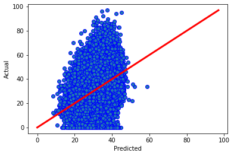

```python
#Overall

ml3 = data.copy()

ml3 = ml3.drop('genre', axis = 1)
ml3 = ml3.drop('artist_name', axis = 1)
ml3 = ml3.drop('track_name', axis = 1)
ml3 = ml3.drop('track_id', axis = 1)
ml3 = ml3.drop('time_signature', axis = 1)
ml3 = ml3.drop('key', axis = 1)
ml3 = ml3.drop('mode', axis = 1)



yo = ml3['popularity']
Xo = ml3.drop('popularity', axis = 1)

X_traino, X_testo, y_traino, y_testo = train_test_split(Xo, yo, test_size = 0.30)

reg = LinearRegression()

#fitting the model with the training data
reg.fit(X_traino, y_traino)

#printing out parameters
print("Coefficients: ", reg.coef_)
print("Intercept: ", reg.intercept_)

#predict based on testing data
y_preo = reg.predict(X_testo)

#calculate coefficient of determination
scre_o = r2_score(y_testo, y_preo)

#calculate MAE
mae_o = mean_absolute_error(y_testo, y_preo)


#compute Root Mean Square Error (RMSE) -- the standard deviation of the residuals
rmse_o = np.sqrt(mean_squared_error(y_testo, y_preo))

print("")
print("R^2 Score: ", scre_o)
print("MAE: ", mae_o)
print("RMSE: ", rmse_o)

#plot
fig, ax = plt.subplots()
ax.scatter(y_preo, y_testo, edgecolors=(0, 0, 1))
ax.plot([y_testo.min(), y_testo.max()], [y_testo.min(), y_testo.max()], 'r', lw=3)
ax.set_xlabel('Predicted')
ax.set_ylabel('Actual')
plt.show()
```

For this overall regression model, we see again that our coefficient of determination (R^2 value) is very low. We also again see that our RMSE value is very large. This again means that the linear regression model is a bad fit and would not do a good job predicting popularity based on audio features. We also see that the MAE (mean absolute error) is around 11.5. The MAE is the absolute difference between the target value and the value predicted by the model. This is a pretty high value which again means the linear regression model is not a good fit.

What we found was that the linear regression model we created was not actually able to predict popularity well. We are able to see this throughout the different models we created based on key relationships, and the overall model we created. We are able to determine this based on having our model learn on a section of test data, and then testing it on our test data. We found that it underperformed in the key regression model metrics that are used to evaluate the performance.

**LINEAR REGRESSION (VALENCE)**

First, we are going to look at the relationship we saw betweem danceability and valence along with the interaction variables energy and loudness.

```python
ml4 = data.copy()
yvd = ml4['valence']
Xvd = ml4.drop('valence', axis = 1)

X_trainvd, X_testvd, y_trainvd, y_testvd = train_test_split(Xvd, yvd, test_size = 0.3)
X_trainvd = X_trainvd.assign(valence = y_trainvd)

#fitting the model with the training data and interaction formula
valdinter_reg = smf.ols(formula = 'valence ~ danceability*energy*loudness', data = X_trainvd).fit()

print("Parameters: ", valdinter_reg.params)

#predict based on testing data
valdint_y_pre = valdinter_reg.predict(X_test)

#calculate coefficient of determination
rsquvd = valdinter_reg.rsquared


#compute Root Mean Square Error (RMSE) -- the standard deviation of the residuals
rmsevd = np.sqrt(mean_squared_error(y_testvd, valdint_y_pre))

print("RMSE: ", rmsevd)
print("Coefficient of Determination (R^2): ", rsquvd)
```

```
Parameters:  Intercept                      -0.068081
danceability                    0.676719
energy                          0.399618
danceability:energy            -0.214529
loudness                       -0.000548
danceability:loudness          -0.002476
energy:loudness                 0.023643
danceability:energy:loudness   -0.038758
dtype: float64
RMSE:  0.33188720318567283
Coefficient of Determination (R^2):  0.4487698412405293
```

Right off the bat, we see a much higher coefficient of determination in comparison to the ones we saw in the linear regression models for popularity (higher than 0.4 in comparison to the others being around 0.1). While it is still not very high, it does mean that the model is at least accounting for a good portion of the variance we see in the data. The RMSE is also around 0.33 which is notably lower than some of the others. This makes it clear that this model does have a lower squared difference between the target value and the predicted value. This again means that this is a much better model than the ones we looked at for popularity. Thus, this linear regression model using the interaction between danceability, loudness, and energy to predict valence is a somewhat decent representation, though not fantastic.

We are now going to look at the overall model. We will use all the essential audio features to create a model.

```
Coefficients:  [-2.06515944e-03  9.27963659e-02  7.84460446e-01 -1.19696238e-07
  4.30769914e-01 -8.74842939e-02 -2.20443310e-02 -5.56696001e-03
 -2.33882349e-01  6.14283321e-04]
Intercept:  -0.22380015705359863
R^2 Score:  0.4954893781120261
MAE:  0.15639224584215322
RMSE:  0.19531006925488464
```

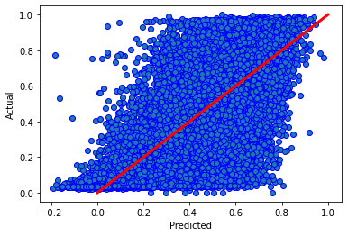

```python
ml5 = data.copy()

ml5 = ml5.drop('genre', axis = 1)
ml5 = ml5.drop('artist_name', axis = 1)
ml5 = ml5.drop('track_name', axis = 1)
ml5 = ml5.drop('track_id', axis = 1)
ml5 = ml5.drop('time_signature', axis = 1)
ml5 = ml5.drop('key', axis = 1)
ml5 = ml5.drop('mode', axis = 1)


yvo = ml5['valence']
Xvo = ml5.drop('valence', axis = 1)

X_trainvo, X_testvo, y_trainvo, y_testvo = train_test_split(Xvo, yvo, test_size = 0.30)

regvo = LinearRegression()

#fitting the model with the training data
regvo.fit(X_trainvo, y_trainvo)

#printing out parameters
print("Coefficients: ", regvo.coef_)
print("Intercept: ", regvo.intercept_)

#predict based on testing data
y_prevo = regvo.predict(X_testvo)

#calculate coefficient of determination
screvo = r2_score(y_testvo, y_prevo)

#calculate MAE
maevo = mean_absolute_error(y_testvo, y_prevo)


#compute Root Mean Square Error (RMSE) -- the standard deviation of the residuals
rmsevo = np.sqrt(mean_squared_error(y_testvo, y_prevo))

print("R^2 Score: ", screvo)
print("MAE: ", maevo)
print("RMSE: ", rmsevo)

#plot
fig, ax = plt.subplots()
ax.scatter(y_prevo, y_testvo, edgecolors=(0, 0, 1))
ax.plot([y_testvo.min(), y_testvo.max()], [y_testvo.min(), y_testvo.max()], 'r', lw=3)
ax.set_xlabel('Predicted')
ax.set_ylabel('Actual')
plt.show()
```

For this overall regression model, we see again that our coefficient of determination (R^2 value) is somewhat high (around 0.5). We also again see that our RMSE value is pretty low (around 0.19-0.2). This again means that the linear regression model is a somewhat decent b fit and would do maybe an okay job predicting valence based on audio features. We also see that the MAE (mean absolute error) is around 0.15. The MAE is the absolute difference between the target value and the value predicted by the model. This is a pretty low value which again means that the linear regression model is a decent fit.

What we found was that the linear regression model we created was a decent representation of this data and was able to somewhat predict valence based on audio features. We are able to see this throughout the different models we created based on key relationships, and the overall model we created. We are able to determine this based on having our model learn on a section of test data, and then testing it on our test data.

## **8. Machine Learning: Decision Trees**

**Decision Tree**

A decision tree is a representation of data in a form where options can be viewed in consequence with cause and effect. In its visual representation, decision trees show the full set of paths and options for paths given a starting point. In certain cases, weights can also be assigned to paths to optimize for efficiency and effectiveness. The primary goal is to depict decision processing and in this, show all possible outcomes. We have again deciced to create different decision trees. One to predict populariyt and the other for valence. We decided to create two overall ones (one for each).

Here are some additional resources and documentation that you might want to familiarize yourself: https://www.geeksforgeeks.org/python-decision-tree-regression-using-sklearn/ https://scikit-learn.org/stable/modules/generated/sklearn.tree.DecisionTreeRegressor.html

```python
from sklearn.tree import DecisionTreeRegressor
from sklearn import tree
import sklearn
```

**DECISION TREES (POPULARITY)**

```python
ml6 = data.copy()

ml6 = ml6.drop('genre', axis = 1)
ml6 = ml6.drop('artist_name', axis = 1)
ml6 = ml6.drop('track_name', axis = 1)
ml6 = ml6.drop('track_id', axis = 1)
ml6 = ml6.drop('time_signature', axis = 1)
ml6 = ml6.drop('key', axis = 1)
ml6 = ml6.drop('mode', axis = 1)

#split the data

ypdt = ml6['popularity']
Xpdt = ml6.drop('popularity', axis = 1)

X_trainpdt, X_testpdt, y_trainpdt, y_testpdt = train_test_split(Xpdt, ypdt, test_size = 0.30)

#initilize the tree with a maxdepth of 10
pdttree = DecisionTreeRegressor(max_depth = 10)

#fit the model with the training data
pdttree.fit(X_trainpdt, y_trainpdt)

#predict based on testing data
y_prepdt = pdttree.predict(X_testpdt)

#calculate coefficient of determination
screpdt = r2_score(y_testpdt, y_prepdt)


#compute Root Mean Square Error (RMSE) -- the standard deviation of the residuals
rmsepdt = np.sqrt(mean_squared_error(y_testpdt, y_prepdt))


print("R^2 Score: ", screpdt)
print("RMSE: ", rmsepdt)
```

```
R^2 Score:  0.2274462623466269
RMSE:  13.994719297814461
```

This is reflective of what we saw in the popularity linear regression model. A low R^2 value and a high RMSE. This again therefore suggests that this model is not a good fit.

**DECISION TREES (VALENCE)**

```python
ml7 = data.copy()

ml7 = ml7.drop('genre', axis = 1)
ml7 = ml7.drop('artist_name', axis = 1)
ml7 = ml7.drop('track_name', axis = 1)
ml7 = ml7.drop('track_id', axis = 1)
ml7 = ml7.drop('time_signature', axis = 1)
ml7 = ml7.drop('key', axis = 1)
ml7 = ml7.drop('mode', axis = 1)

#split the data
yvdt = ml7['valence']
Xvdt = ml7.drop('valence', axis = 1)

X_trainvdt, X_testvdt, y_trainvdt, y_testvdt = train_test_split(Xvdt, yvdt, test_size = 0.30)

#initilize the tree with a maxdepth of 10
vdtree = DecisionTreeRegressor(max_depth = 10)

#fit the model with the training data
vdtree.fit(X_trainvdt, y_trainvdt)

#predict based on testing data
y_prevdt = vdtree.predict(X_testvdt)

#calculate coefficient of determination
screvdt = r2_score(y_testvdt, y_prevdt)


#compute Root Mean Square Error (RMSE) -- the standard deviation of the residuals
rmsevdt = np.sqrt(mean_squared_error(y_testvdt, y_prevdt))


print("R^2 Score: ", screvdt)
print("RMSE: ", rmsevdt)
```

```
R^2 Score:  0.5244531867859129
RMSE:  0.18994156073112442
```

This is similar to the results we got from the valence linear regression model. However, it does seem to be performing slighlty better. The R^2 value is a bit higher and the RMSE is very slightly lower. This again appears to be a somewhat decent model for valence.

The decision tree that looks at valence is more accurate than that of popularity because when we look at the results, it can be seen that the coefficient and the RMSE are more accurate for the valence whereas this is not the case for popularity. This decision tree actually showed the highest coefficient of any of the models, showing the power of the decision tree given the right circumstances. Decision trees are optimal for looking at the likelihood of all possible outcomes, so it makes sense that in this particular usage, it would be able to use the valence data to create a good chance at correct prediction. Popularity it seems is more difficult to predict, due to the vast number of variables and components that go into something being “popular” that we can see that popularity itself is not something that is easily quantifiable or predictable mathematically.

## **9. Conclusion**

As the entertainment industry continues to evolve into something entirely different from what we know now, we will see more and more uses of prediction software to best optimize for business growth and profit. While it is up to interpretation to determine if this is really something that is good or bad for the music industry and art in general, our data was able to provide some fascinating conclusions nonetheless that show that the future may not be as cut and dry as software predicting what music will make the next best hit.

We found that popularity is rather difficult to predict when it comes to music. So many genres and artists that can move between genres as well as trends changing in such different ways makes it difficult to determine what will be next to take over the charts. Thankfully, the Spotify API has a lot of insight into what attributes a song has, including things we would not have thought of like danceability or acousticness. Using this and learning about how they are scaled for comparison with other songs, we were able to create models in accordance.

While some relationships could be found, and valence in particular seemed to be fairly predictable, the correlations with popularity remained difficult through trial and error. While we are sure Spotify has a way of predicting to some extent where popularity will go, it is not very simple and it clearly is not something that can be represented as an algorithm of just a few variables. For example, we do not know the prevalence and success rate of A&R when it comes to the effect on popularity or how Spotify itself plays a role in promoting artists.

While many think that using software to create the next trends in music is a regression in the industry, it is not necessarily inevitable. Unique artistic expression clearly still has its place in creating popularity. The fact that predictability of popularity is not as easy as it seems when it comes to music means that we will continue to see unique new takes on genres move forward and become popular to set new precedents. Given more time, we also would want to think about what new medium could replace that of music streaming, and how that could impact trends in the music industry. Hopefully our tutorial can provide some insight into the streaming music industry and the music industry as a whole a bit more to others, but regardless we definitely gained a lot from this tutorial ourselves.